#Project- House Price of Saratoga County, New York

#1. Descriptive Statistics #Read the Dataset.

```r
HP<-read.csv("C:\\Users\\Sweta\\Documents\\Data\\house price.csv", header=T)
attach(HP)
names(HP)
```

```
##  [1] "Price"         "Lot.Size"      "Waterfront"    "Age"
##  [5] "Land.Value"    "New.Construct" "Central.Air"   "Fuel.Type"
##  [9] "Heat.Type"     "Sewer.Type"    "Living.Area"   "Pct.College"
## [13] "Bedrooms"      "Fireplaces"    "Bathrooms"     "Rooms"
```

#Remove rows which has missing values in the dataframe

```r
HP <- na.omit(HP)
```

#Check the first few rows of the dataframe

```r
head(HP)
```

```
##    Price Lot.Size Waterfront Age Land.Value New.Construct Central.Air Fuel.Type
## 1 132500     0.09          0  42      50000             0           0  Electric
## 2 181115     0.92          0   0      22300             0           0       Gas
## 3 109000     0.19          0 133       7300             0           0       Gas
## 4 155000     0.41          0  13      18700             0           0       Gas
## 5  86060     0.11          0   0      15000             1           1       Gas
## 6 120000     0.68          0  31      14000             0           0       Gas
##   Heat.Type Sewer.Type Living.Area Pct.College Bedrooms Fireplaces Bathrooms
## 1  Electric    Private         906          35        2          1       1.0
## 2 Hot Water    Private        1953          51        3          0       2.5
## 3 Hot Water     Public        1944          51        4          1       1.0
## 4   Hot Air    Private        1944          51        3          1       1.5
## 5   Hot Air     Public         840          51        2          0       1.0
## 6   Hot Air    Private        1152          22        4          1       1.0
##   Rooms
## 1     5
## 2     6
## 3     8
## 4     5
## 5     3
## 6     8
```

#Check the data types of the dataframe

```r
str(HP)
```

```
## 'data.frame':    1731 obs. of  16 variables:
##  $ Price        : int  132500 181115 109000 155000 86060 120000 153000 170000 90000 122900 ...
##  $ Lot.Size     : num  0.09 0.92 0.19 0.41 0.11 0.68 0.4 1.21 0.83 1.94 ...
##  $ Waterfront   : int  0 0 0 0 0 0 0 0 0 0 ...
##  $ Age          : int  42 0 133 13 0 31 33 23 36 4 ...
##  $ Land.Value   : int  50000 22300 7300 18700 15000 14000 23300 14600 22200 21200 ...
##  $ New.Construct: int  0 0 0 0 1 0 0 0 0 0 ...
##  $ Central.Air  : int  0 0 0 0 1 0 0 0 0 0 ...
##  $ Fuel.Type    : chr  "Electric" "Gas" "Gas" "Gas" ...
##  $ Heat.Type    : chr  "Electric" "Hot Water" "Hot Water" "Hot Air" ...
##  $ Sewer.Type   : chr  "Private" "Private" "Public" "Private" ...
##  $ Living.Area  : int  906 1953 1944 1944 840 1152 2752 1662 1632 1416 ...
##  $ Pct.College  : int  35 51 51 51 51 22 51 35 51 44 ...
##  $ Bedrooms     : int  2 3 4 3 2 4 4 4 3 3 ...
##  $ Fireplaces   : int  1 0 1 1 0 1 1 1 0 0 ...
##  $ Bathrooms    : num  1 2.5 1 1.5 1 1 1.5 1.5 1.5 1.5 ...
##  $ Rooms        : int  5 6 8 5 3 8 8 9 8 6 ...
```

#Change Fireplaces, Bedrooms, Bathrooms and Rooms into factor variables

```r
HP$Fireplaces <- as.factor(HP$Fireplaces)
HP$Bedrooms <- as.factor(HP$Bedrooms)
HP$Bathrooms <- as.factor(HP$Bathrooms)
HP$Rooms <- as.factor(HP$Rooms)
```

#Change the Waterfront, New.Construct, Central.Air into factor variable and turn the numbers 0 and 1 into “No” and “Yes” respectively.

```r
HP$Waterfront=factor(HP$Waterfront,labels=c("No","Yes"))
HP$Central.Air=factor(HP$Central.Air,labels=c("No","Yes"))
HP$New.Construct=factor(HP$New.Construct,labels=c("No","Yes"))
```

```r
options(scipen = 999)
```

#Mean

```r
sapply(Filter(is.numeric, HP), FUN = mean, na.rm = TRUE)
```

```
##          Price       Lot.Size            Age     Land.Value    Living.Area
## 211710.3362218      0.5007972     28.1473137  34549.7515887   1753.6915078
##    Pct.College
##     55.5696129
```

#Median

```r
sapply(Filter(is.numeric, HP), FUN = median, na.rm = TRUE)
```

```
##       Price    Lot.Size         Age  Land.Value Living.Area Pct.College
##   189900.00        0.37       19.00    25000.00     1632.00       57.00
```

#five number summary

```r
sapply(Filter(is.numeric, HP), FUN = fivenum, na.rm = TRUE)
```

```
##       Price Lot.Size Age Land.Value Living.Area Pct.College
## [1,]   5000     0.00   0        200       616.0          20
## [2,] 145000     0.17  13      15100      1300.0          52
## [3,] 189900     0.37  19      25000      1632.0          57
## [4,] 258193     0.54  34      40200      2135.5          64
## [5,] 775000    12.20 225     412600      5228.0          82
```

#Calculate the range of house price in Saratoga.

```r
range(Price)
```

```
## [1]   5000 775000
```

#Histogram of continuous variables #Histogram for House Price

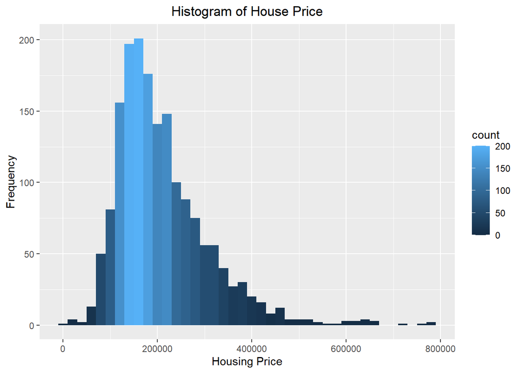

```r
library(ggplot2)
ggplot(HP, aes(x = Price, fill = ..count..)) + geom_histogram(binwidth = 20000) + ggtitle("Histogram of House Price") + ylab("Frequency") + xlab("Housing Price") + theme(plot.title = element_text(hjust = 0.5))
```

#Histogram for Lot.Size

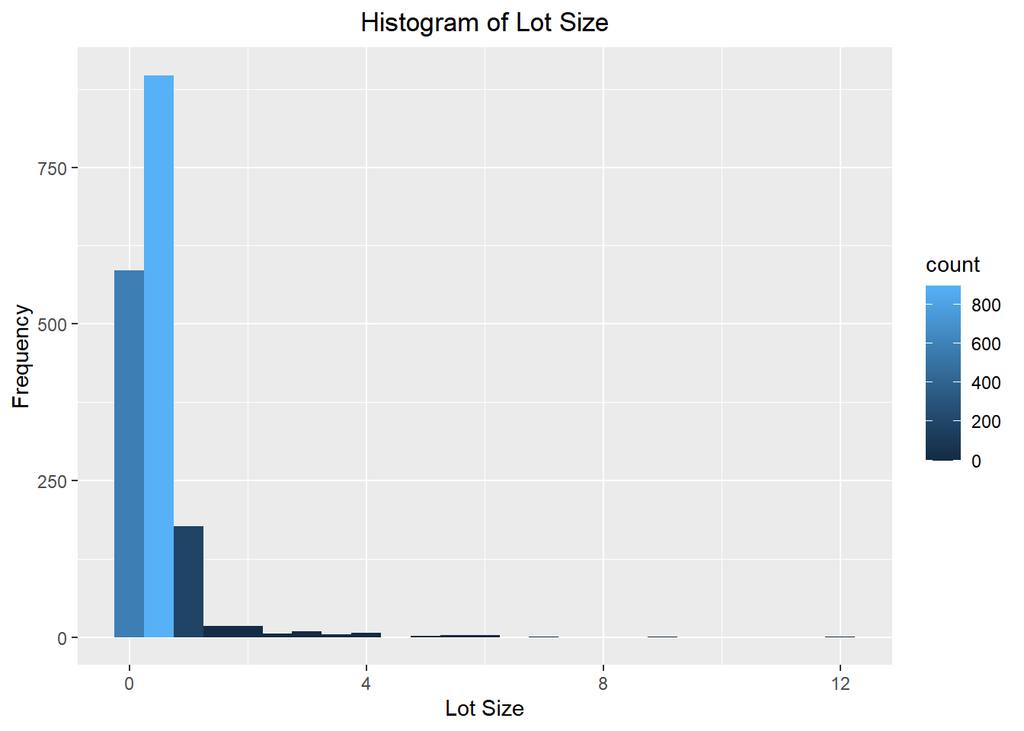

```r
ggplot(HP, aes(x = Lot.Size, fill = ..count..)) + geom_histogram(binwidth = 0.5) + ggtitle("Histogram of Lot Size") + ylab("Frequency") + xlab("Lot Size") + theme(plot.title = element_text(hjust = 0.5))
```

#Histogram for Age

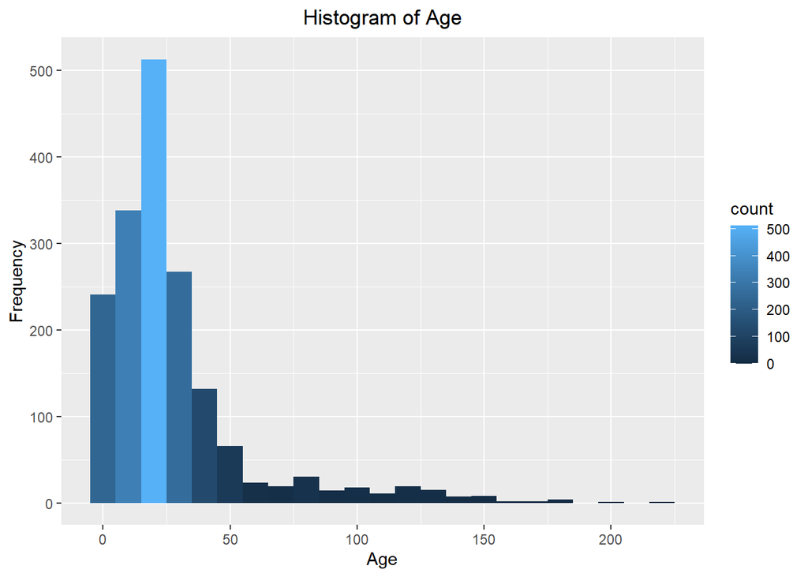

```r
ggplot(HP, aes(x = Age, fill = ..count..)) + geom_histogram(binwidth = 10) + ggtitle("Histogram of Age") + ylab("Frequency") + xlab("Age") + theme(plot.title = element_text(hjust = 0.5))
```

#Histogram for Land value

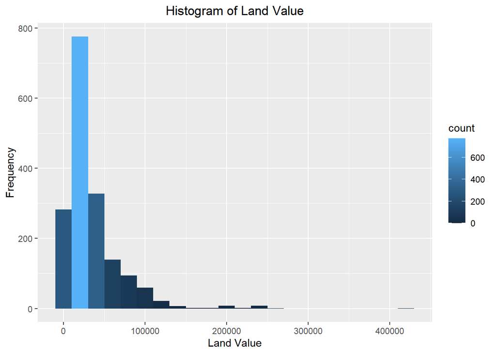

```r
ggplot(HP, aes(x = Land.Value, fill = ..count..)) + geom_histogram(binwidth = 20000) + ggtitle("Histogram of Land Value") + ylab("Frequency") + xlab("Land Value") + theme(plot.title = element_text(hjust = 0.5))
```

#Histogram of percent of neighborhood that graduated college

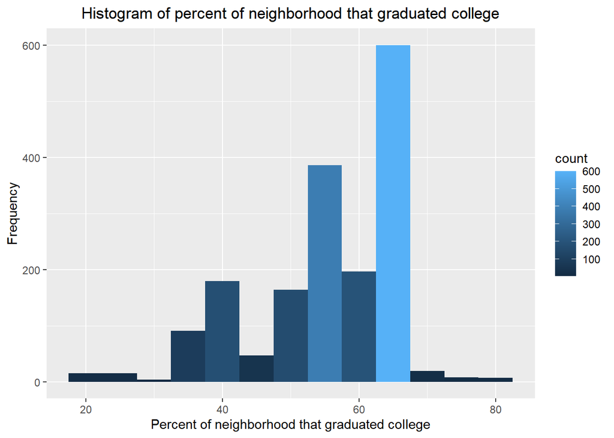

```r
ggplot(HP, aes(x = Pct.College, fill = ..count..)) + geom_histogram(binwidth = 5) + ggtitle("Histogram of percent of neighborhood that graduated college") + ylab("Frequency") + xlab("Percent of neighborhood that graduated college") + theme(plot.title = element_text(hjust = 0.5))
```

#Histogram of Living Area

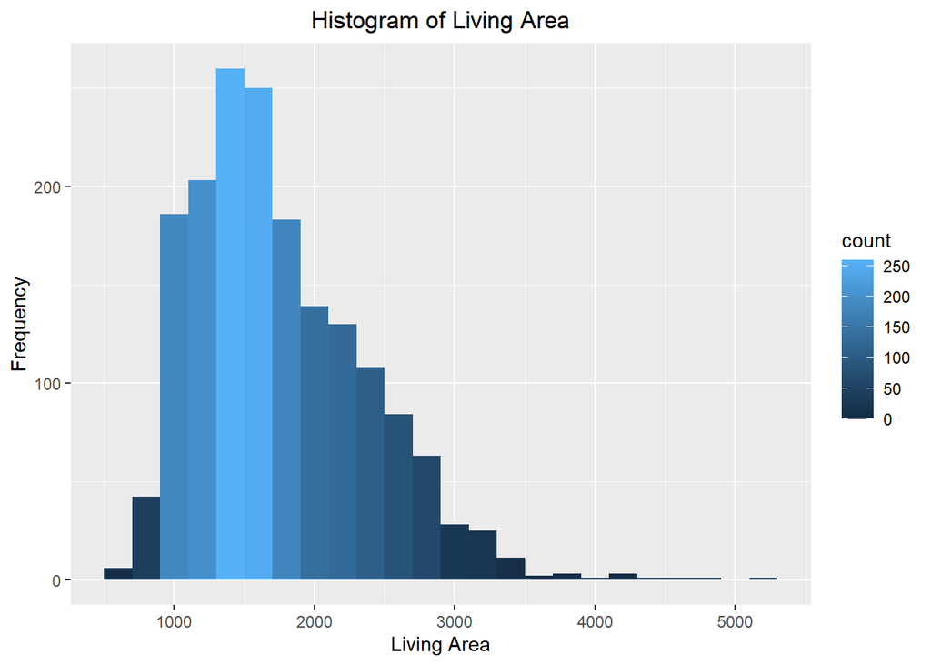

```r
ggplot(HP, aes(x = Living.Area, fill = ..count..)) + geom_histogram(binwidth = 200) + ggtitle("Histogram of Living Area") + ylab("Frequency") + xlab("Living Area") + theme(plot.title = element_text(hjust = 0.5))
```

#Bar chart of Factor variables

#Distribution of waterfront

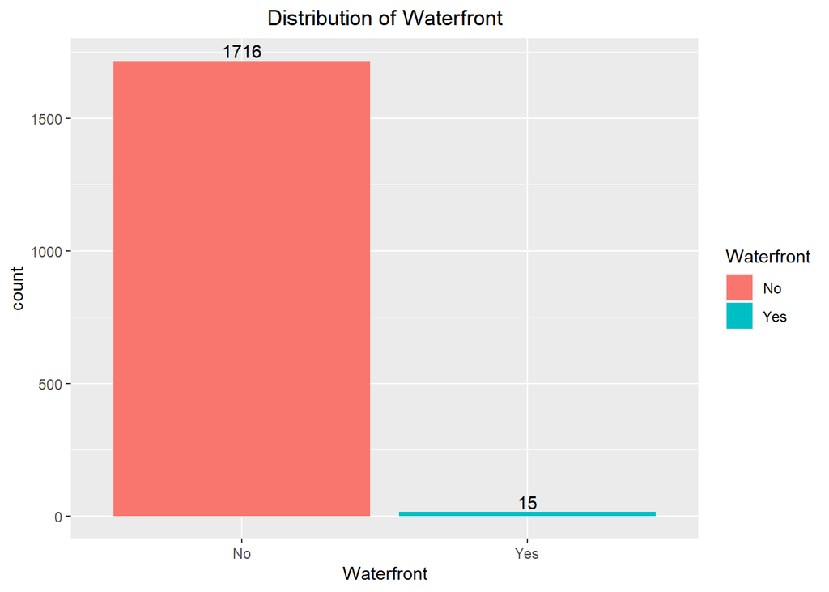

```r
ggplot(HP, aes(x = Waterfront, fill = Waterfront )) +
geom_bar()+ ggtitle("Distribution of Waterfront")+
theme(plot.title = element_text(hjust = 0.5))+ geom_text(stat='count',aes(label=..count..),vjust=-0.25)
```

#Distribution of New Construction

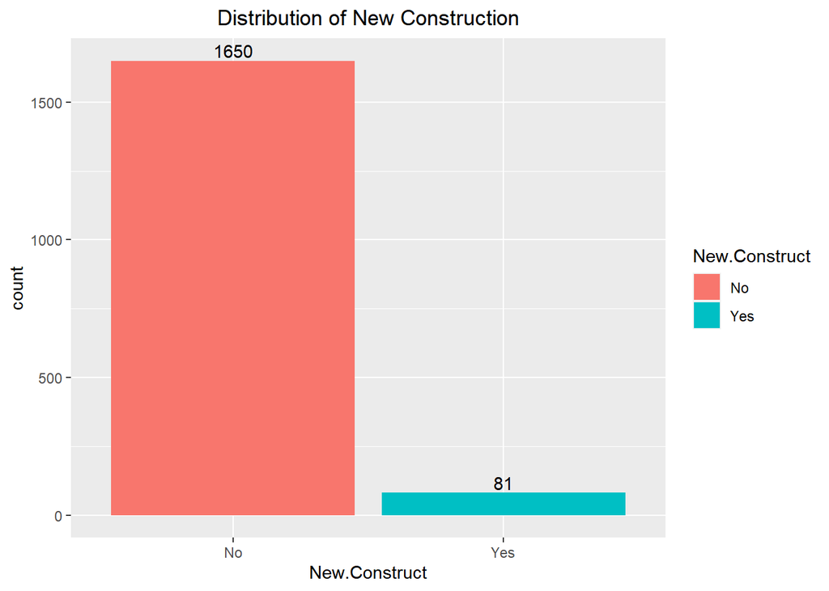

```r
ggplot(HP, aes(x = New.Construct, fill = New.Construct )) +
geom_bar()+ ggtitle("Distribution of New Construction")+
theme(plot.title = element_text(hjust = 0.5))+ geom_text(stat='count',aes(label=..count..),vjust=-0.25)
```

#Distribution of Central Air

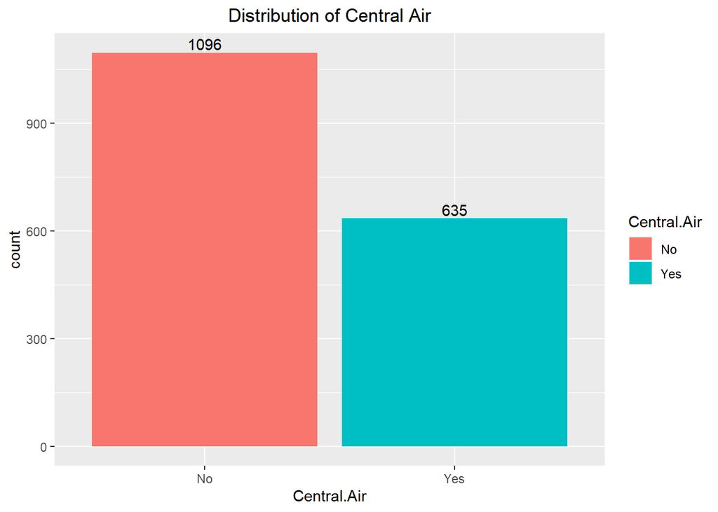

```r
ggplot(HP, aes(x = Central.Air, fill = Central.Air )) +
geom_bar()+ ggtitle("Distribution of Central Air")+
theme(plot.title = element_text(hjust = 0.5))+ geom_text(stat='count',aes(label=..count..),vjust=-0.25)
```

#Distribution of different Fuel type

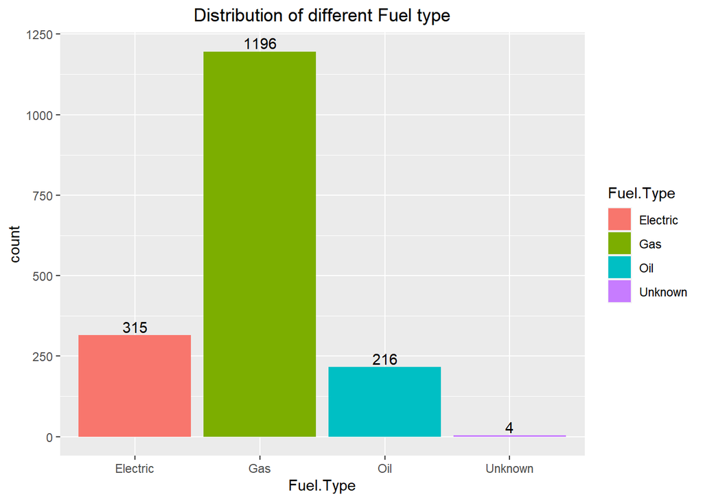

```r
ggplot(HP, aes(x = Fuel.Type, fill = Fuel.Type )) +
geom_bar()+ ggtitle("Distribution of different Fuel type")+
theme(plot.title = element_text(hjust = 0.5))+ geom_text(stat='count',aes(label=..count..),vjust=-0.25)
```

#Distribution of different Heat type

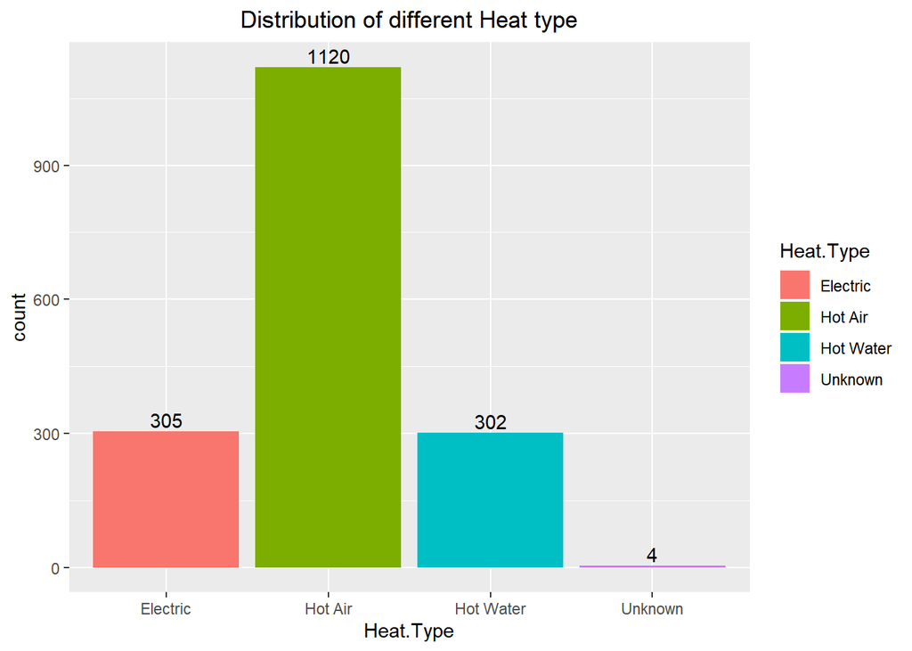

```r
ggplot(HP, aes(x = Heat.Type, fill = Heat.Type )) +
geom_bar()+ ggtitle("Distribution of different Heat type")+
theme(plot.title = element_text(hjust = 0.5))+ geom_text(stat='count',aes(label=..count..),vjust=-0.25)
```

#Distribution of different Sewer type

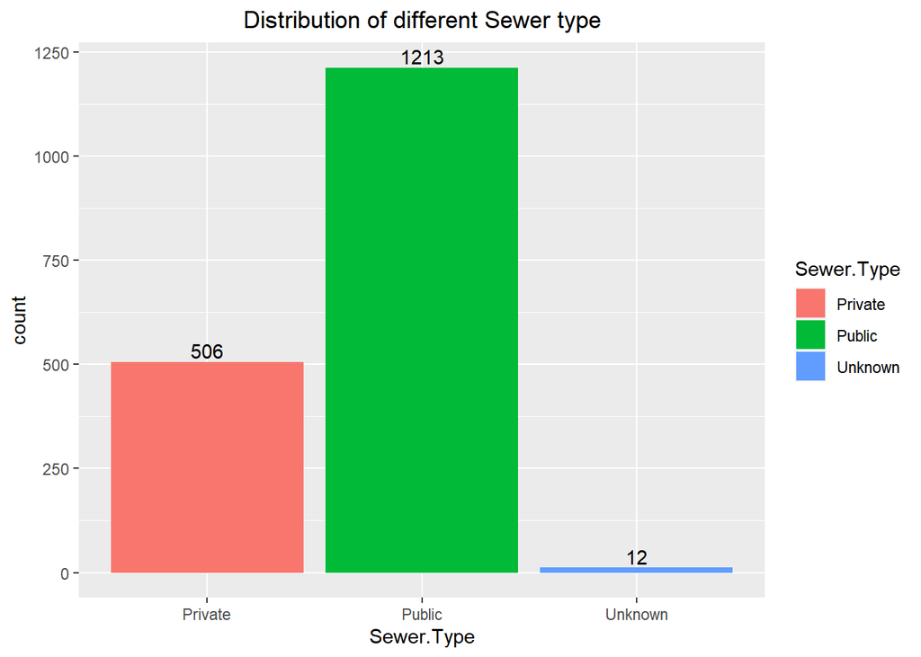

```r
ggplot(HP, aes(x = Sewer.Type, fill = Sewer.Type )) +
geom_bar()+ ggtitle("Distribution of different Sewer type")+
theme(plot.title = element_text(hjust = 0.5))+ geom_text(stat='count',aes(label=..count..),vjust=-0.25)
```

#Distribution of Bedrooms

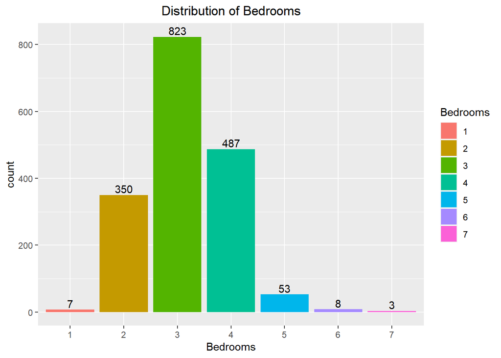

```r
ggplot(HP, aes(x = Bedrooms, fill = Bedrooms )) +
geom_bar()+ ggtitle("Distribution of Bedrooms")+
theme(plot.title = element_text(hjust = 0.5))+ geom_text(stat='count',aes(label=..count..),vjust=-0.25)
```

#Distribution of Fireplaces

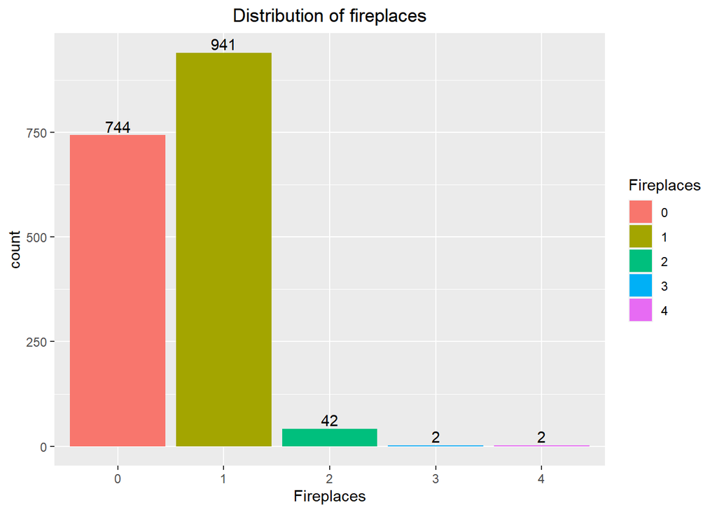

```r
ggplot(HP, aes(x = Fireplaces, fill = Fireplaces )) +
geom_bar()+ ggtitle("Distribution of fireplaces")+
theme(plot.title = element_text(hjust = 0.5))+ geom_text(stat='count',aes(label=..count..),vjust=-0.25)
```

#Distribution of Bathrooms

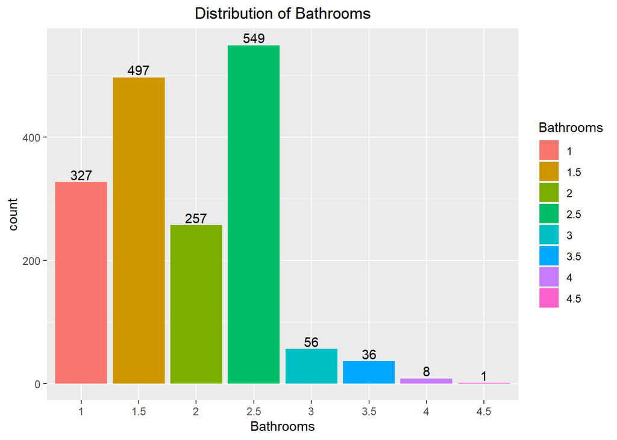

```r
ggplot(HP, aes(x = Bathrooms, fill = Bathrooms )) +
geom_bar()+ ggtitle("Distribution of Bathrooms")+
theme(plot.title = element_text(hjust = 0.5))+ geom_text(stat='count',aes(label=..count..),vjust=-0.25)
```

#Distribution of Rooms

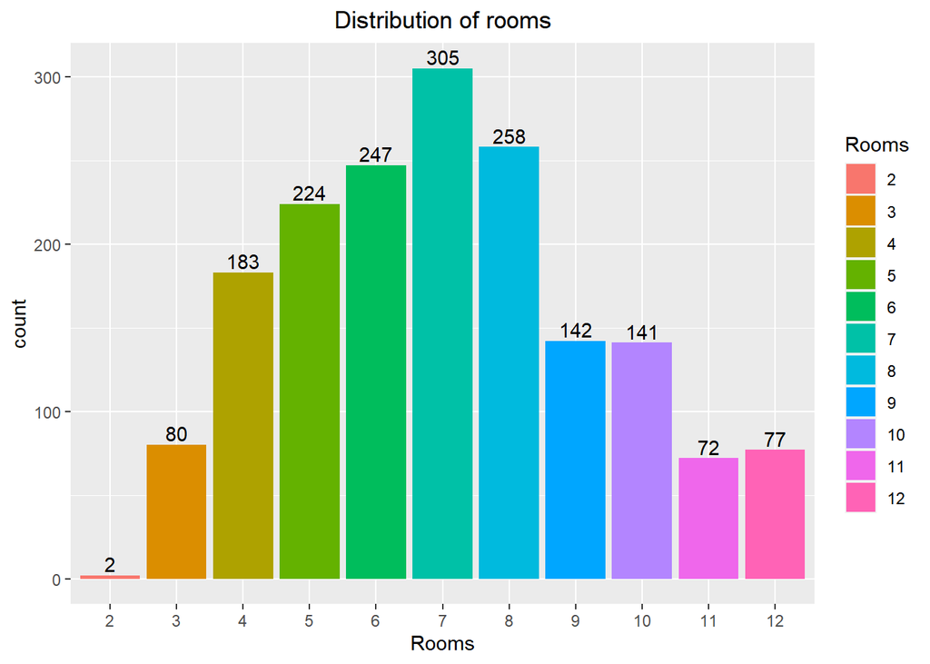

```r
ggplot(HP, aes(x = Rooms, fill = Rooms )) +
geom_bar()+ ggtitle("Distribution of rooms")+
theme(plot.title = element_text(hjust = 0.5))+ geom_text(stat='count',aes(label=..count..),vjust=-0.25)
```

#Correlation Analysis

```r
library(ggcorrplot)
library(car)
HPCorr <- data.frame(Price, Lot.Size,Age, Land.Value, Living.Area, Pct.College, Bedrooms, Fireplaces, Bathrooms, Rooms)
corr <- cor(HPCorr)
round(corr, 2)
```

```
##             Price Lot.Size   Age Land.Value Living.Area Pct.College Bedrooms
## Price        1.00     0.16 -0.19       0.58        0.71        0.20     0.40
## Lot.Size     0.16     1.00 -0.01       0.06        0.16       -0.03     0.11
## Age         -0.19    -0.01  1.00      -0.02       -0.18       -0.04     0.02
## Land.Value   0.58     0.06 -0.02       1.00        0.42        0.23     0.20
## Living.Area  0.71     0.16 -0.18       0.42        1.00        0.21     0.66
## Pct.College  0.20    -0.03 -0.04       0.23        0.21        1.00     0.16
## Bedrooms     0.40     0.11  0.02       0.20        0.66        0.16     1.00
## Fireplaces   0.38     0.08 -0.18       0.21        0.48        0.25     0.29
## Bathrooms    0.60     0.08 -0.36       0.30        0.72        0.18     0.46
## Rooms        0.53     0.14 -0.09       0.30        0.73        0.16     0.67
##             Fireplaces Bathrooms Rooms
## Price             0.38      0.60  0.53
## Lot.Size          0.08      0.08  0.14
## Age              -0.18     -0.36 -0.09
## Land.Value        0.21      0.30  0.30
## Living.Area       0.48      0.72  0.73
## Pct.College       0.25      0.18  0.16
## Bedrooms          0.29      0.46  0.67
## Fireplaces        1.00      0.44  0.32
## Bathrooms         0.44      1.00  0.52
## Rooms             0.32      0.52  1.00
```

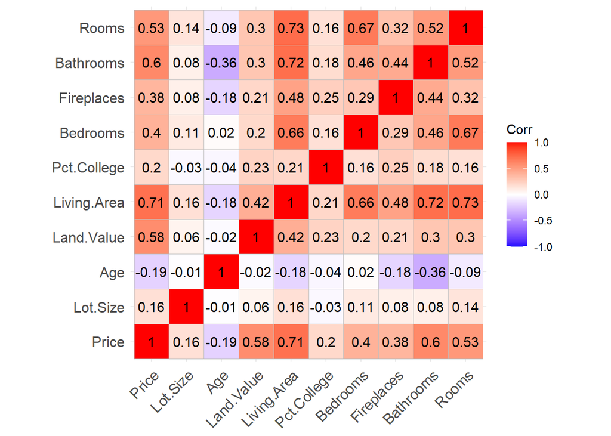

```r
ggcorrplot(corr,lab=TRUE)
```

#Few predictors show strong relationship with house price. Living Area (0.71), Land Value(0.58), bathrooms(0.6) and rooms(0.53) are highly correlated with response variable Price. On the other hand, Rooms, Bedrooms, Bathrooms and Living Area are correlated to each other.

#Variance Inflation Factor

```r
model=lm(Price~ Lot.Size + Age +Land.Value + Living.Area + Pct.College + as.numeric(Bedrooms) + as.numeric(Fireplaces) + as.numeric(Bathrooms) + as.numeric(Rooms), data=HP)
car::vif(model)
```

```
##               Lot.Size                    Age             Land.Value
##               1.035819               1.222638               1.276047
##            Living.Area            Pct.College   as.numeric(Bedrooms)
##               4.108891               1.114403               2.147644
## as.numeric(Fireplaces)  as.numeric(Bathrooms)      as.numeric(Rooms)
##               1.370883               2.402161               2.525071
```

#Scatter plot of Price vs Lot Size & Analysis of Price ~ Lot.Size

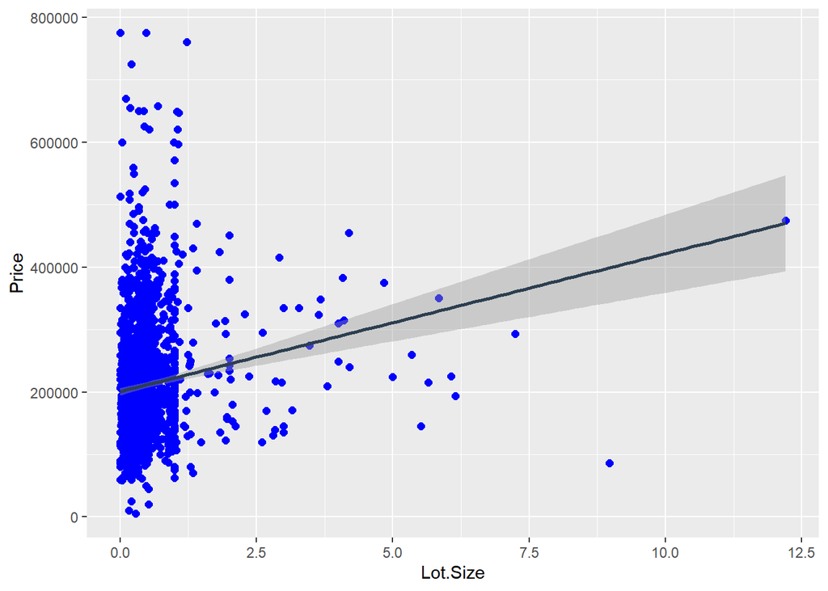

```r
ggplot(HP, aes(x=Lot.Size, y=Price)) +
  geom_point(color='blue', size = 2) +
  geom_smooth(method=lm, color='#2C3E50')
```

```r
model1=lm(Price~Lot.Size,data=HP)
summary(model1)
```

```
##
## Call:
## lm(formula = Price ~ Lot.Size, data = HP)
##
## Residuals:
##     Min      1Q  Median      3Q     Max
## -313017  -64785  -22936   44801  574357
##
## Coefficients:
##             Estimate Std. Error t value             Pr(>|t|)
## (Intercept)   200643       2878  69.706 < 0.0000000000000002 ***
## Lot.Size       22100       3349   6.599       0.000000000055 ***
## ---
## Signif. codes:  0 '***' 0.001 '**' 0.01 '*' 0.05 '.' 0.1 ' ' 1
##
## Residual standard error: 97330 on 1729 degrees of freedom
## Multiple R-squared:  0.02456,    Adjusted R-squared:  0.024
## F-statistic: 43.54 on 1 and 1729 DF,  p-value: 0.000000000055
```

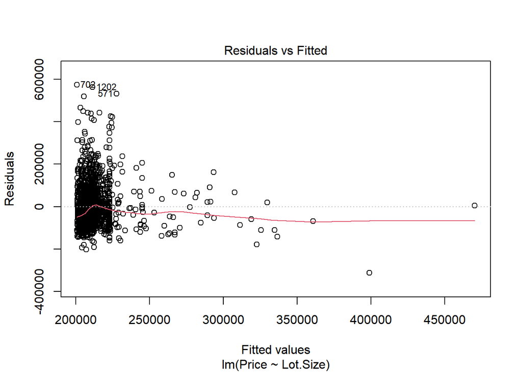

```r
plot(model1, which=1)
```

#Scatter plot of Price vs Age & Analysis of Price ~ Age

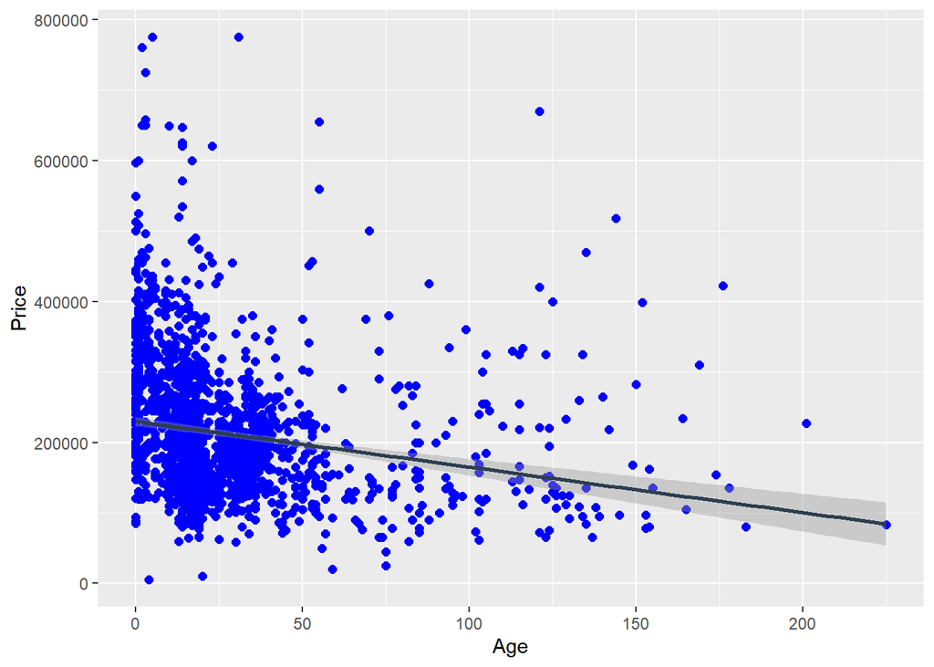

```r
ggplot(HP, aes(x=Age, y=Price)) +
  geom_point(color='blue', size = 2) +
  geom_smooth(method=lm, color='#2C3E50')
```

```r
model2=lm(Price~Age,data=HP)
summary(model2)
```

```
##
## Call:
## lm(formula = Price ~ Age, data = HP)
##
## Residuals:
##     Min      1Q  Median      3Q     Max
## -222321  -66295  -22169   43109  565134
##
## Coefficients:
##              Estimate Std. Error t value             Pr(>|t|)
## (Intercept) 229906.65    3200.76  71.829 < 0.0000000000000002 ***
## Age           -646.47      78.22  -8.264 0.000000000000000277 ***
## ---
## Signif. codes:  0 '***' 0.001 '**' 0.01 '*' 0.05 '.' 0.1 ' ' 1
##
## Residual standard error: 96650 on 1729 degrees of freedom
## Multiple R-squared:  0.038,  Adjusted R-squared:  0.03744
## F-statistic:  68.3 on 1 and 1729 DF,  p-value: 0.0000000000000002765
```

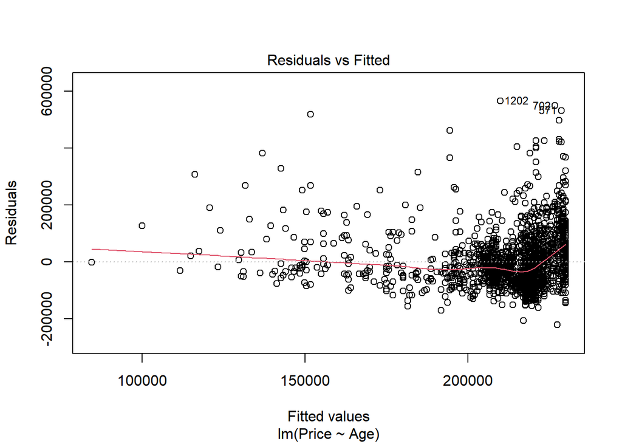

```r
plot(model2, which=1)
```

#Scatter plot of Price vs Land Value & Analysis of Price ~ Land Value

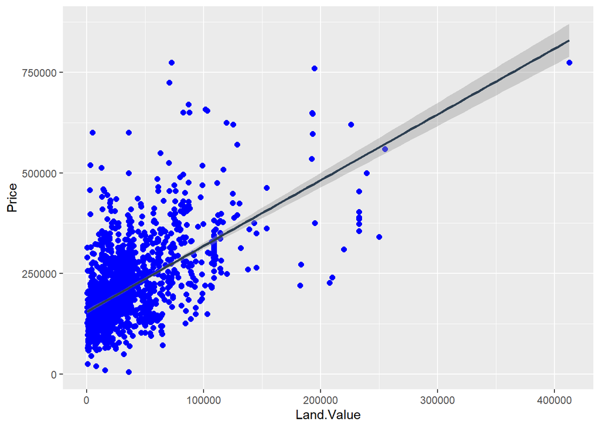

```r
ggplot(HP, aes(x=Land.Value, y=Price)) +
  geom_point(color='blue', size = 2) +
  geom_smooth(method=lm, color='#2C3E50')
```

```r
model3=lm(Price~Land.Value,data=HP)
summary(model3)
```

```
##
## Call:
## lm(formula = Price ~ Land.Value, data = HP)
##
## Residuals:
##     Min      1Q  Median      3Q     Max
## -267746  -49152  -14017   36236  501092
##
## Coefficients:
##                 Estimate   Std. Error t value            Pr(>|t|)
## (Intercept) 155234.41155   2709.83679   57.29 <0.0000000000000002 ***
## Land.Value       1.63463      0.05511   29.66 <0.0000000000000002 ***
## ---
## Signif. codes:  0 '***' 0.001 '**' 0.01 '*' 0.05 '.' 0.1 ' ' 1
##
## Residual standard error: 80220 on 1729 degrees of freedom
## Multiple R-squared:  0.3373, Adjusted R-squared:  0.3369
## F-statistic: 879.8 on 1 and 1729 DF,  p-value: < 0.00000000000000022
```

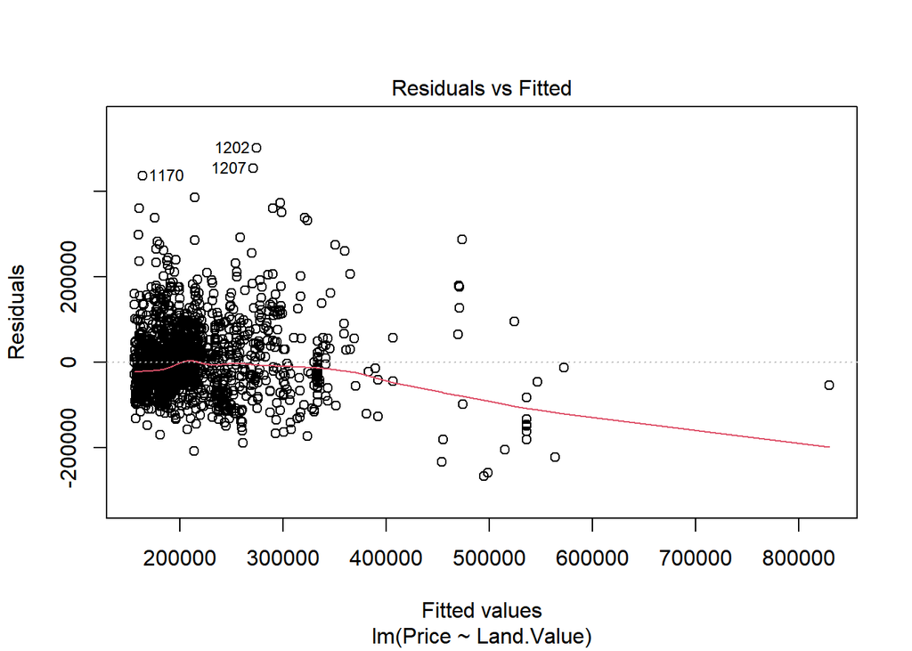

```r
plot(model3, which=1)
```

#Scatter plot of Price vs Living Area & Analysis of Price ~ Living Area

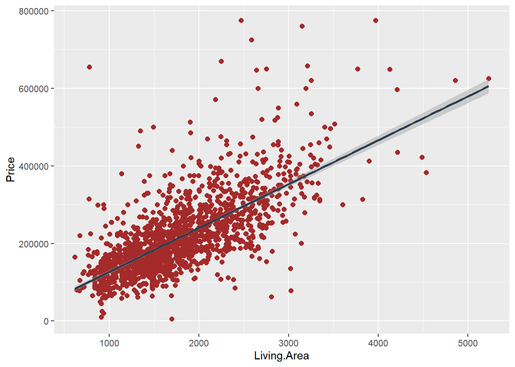

```r
ggplot(HP, aes(x=Living.Area, y=Price)) +
  geom_point(color='brown', size = 2) +
  geom_smooth(method=lm, color='#2C3E50')
```

```r
model4=lm(Price~Living.Area,data=HP)
summary(model4)
```

```
##
## Call:
## lm(formula = Price ~ Living.Area, data = HP)
##
## Residuals:
##     Min      1Q  Median      3Q     Max
## -277098  -39352   -7638   28354  553580
##
## Coefficients:
##             Estimate Std. Error t value             Pr(>|t|)
## (Intercept) 13069.90    4984.18   2.622              0.00881 **
## Living.Area   113.27       2.68  42.271 < 0.0000000000000002 ***
## ---
## Signif. codes:  0 '***' 0.001 '**' 0.01 '*' 0.05 '.' 0.1 ' ' 1
##
## Residual standard error: 69110 on 1729 degrees of freedom
## Multiple R-squared:  0.5082, Adjusted R-squared:  0.5079
## F-statistic:  1787 on 1 and 1729 DF,  p-value: < 0.00000000000000022
```

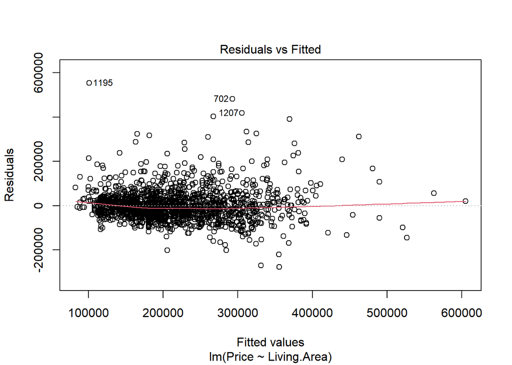

```r
plot(model4, which=1)
```

#Scatter plot of Price vs Pct.College & Analysis of Price ~ Pct.College

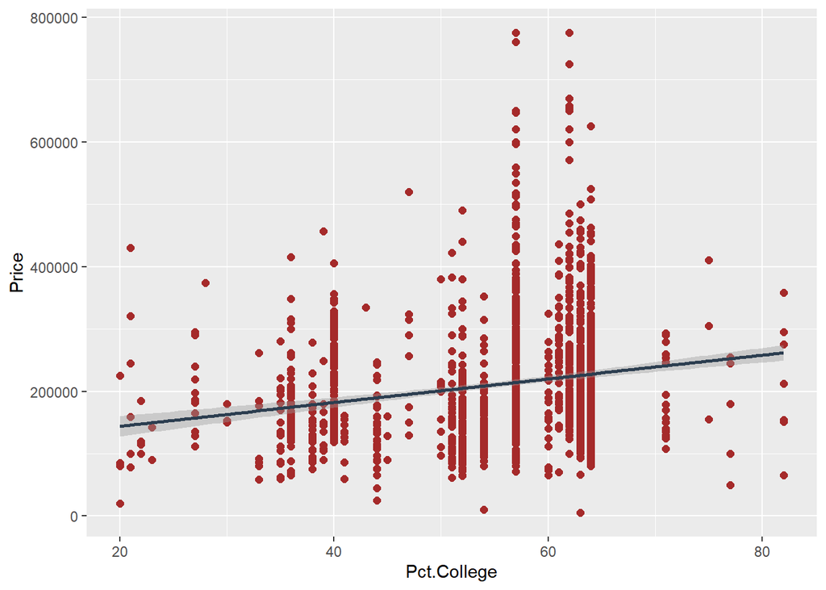

```r
ggplot(HP, aes(x=Pct.College, y=Price)) +
  geom_point(color='brown', size = 2) +
  geom_smooth(method=lm, color='#2C3E50')
```

```r
model5=lm(Price~Pct.College,data=HP)
summary(model5)
```

```
##
## Call:
## lm(formula = Price ~ Pct.College, data = HP)
##
## Residuals:
##     Min      1Q  Median      3Q     Max
## -220827  -64665  -22231   42120  560572
##
## Coefficients:
##             Estimate Std. Error t value            Pr(>|t|)
## (Intercept) 106139.0    12710.6   8.350 <0.0000000000000002 ***
## Pct.College   1899.8      224.9   8.448 <0.0000000000000002 ***
## ---
## Signif. codes:  0 '***' 0.001 '**' 0.01 '*' 0.05 '.' 0.1 ' ' 1
##
## Residual standard error: 96570 on 1729 degrees of freedom
## Multiple R-squared:  0.03964,    Adjusted R-squared:  0.03908
## F-statistic: 71.37 on 1 and 1729 DF,  p-value: < 0.00000000000000022
```

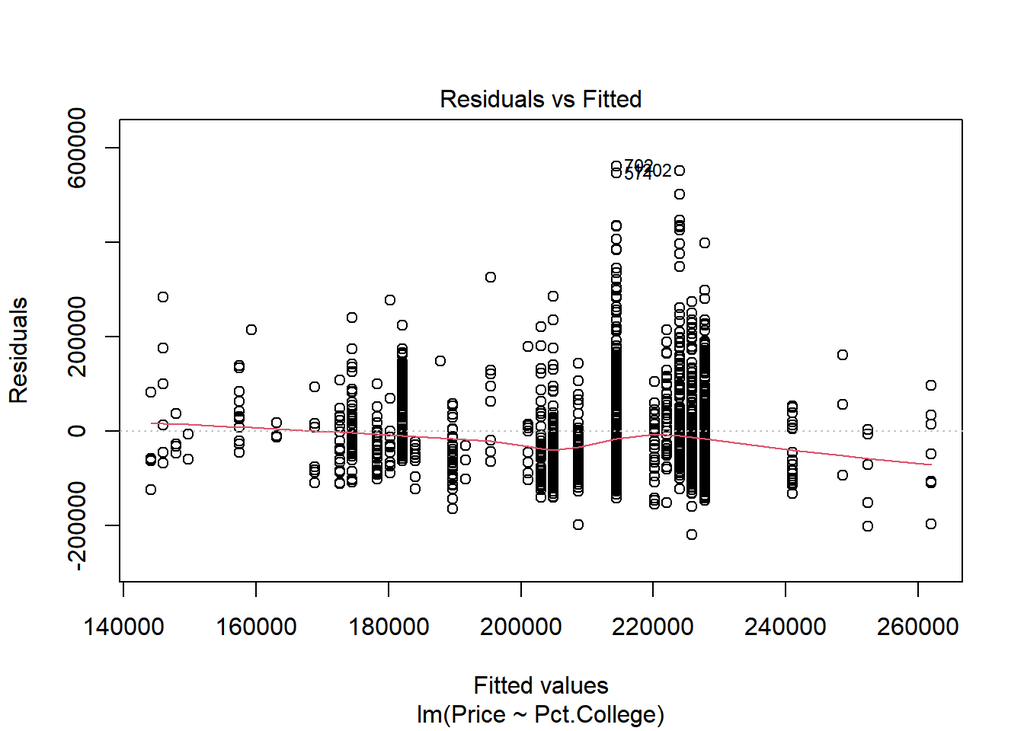

```r
plot(model5, which=1)
```

##Box plot of house price by Bedrooms & Analysis of Price ~ Bedrooms

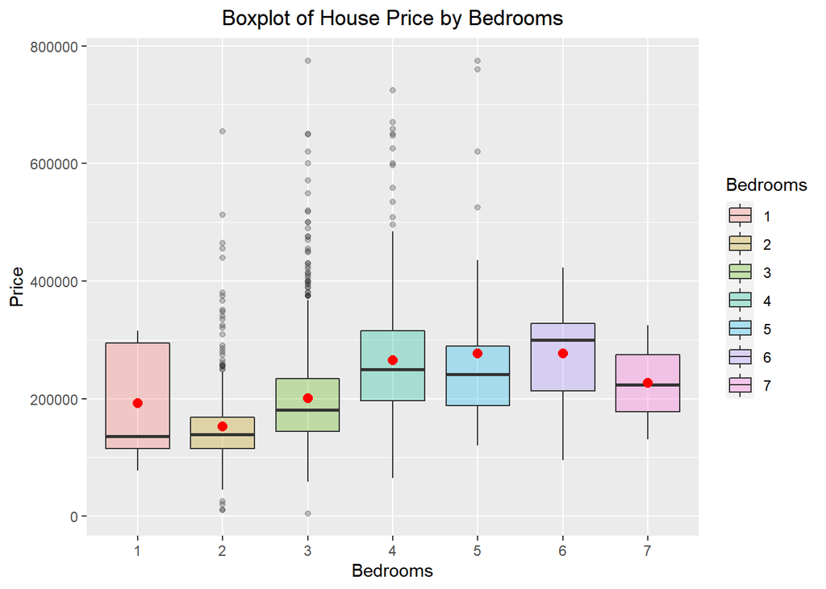

```r
ggplot(HP, aes(x=Bedrooms, y=Price, fill=Bedrooms)) +
  geom_boxplot(alpha=0.3) +
  stat_summary(fun.y=mean, geom="point", shape=20, size=4, color="red", fill="red")+
  ggtitle("Boxplot of House Price by Bedrooms")+
  theme(plot.title = element_text(hjust = 0.5))
```

```r
model6=lm(Price~Bedrooms,data=HP)
summary(model6)
```

```
##
## Call:
## lm(formula = Price ~ Bedrooms, data = HP)
##
## Residuals:
##     Min      1Q  Median      3Q     Max
## -200551  -55407  -16007   32697  574593
##
## Coefficients:
##             Estimate Std. Error t value     Pr(>|t|)
## (Intercept)   192771      33789   5.705 0.0000000136 ***
## Bedrooms2     -40468      34125  -1.186       0.2358
## Bedrooms3       7635      33932   0.225       0.8220
## Bedrooms4      72779      34031   2.139       0.0326 *
## Bedrooms5      83806      35951   2.331       0.0199 *
## Bedrooms6      84557      46267   1.828       0.0678 .
## Bedrooms7      33895      61689   0.549       0.5828
## ---
## Signif. codes:  0 '***' 0.001 '**' 0.01 '*' 0.05 '.' 0.1 ' ' 1
##
## Residual standard error: 89400 on 1724 degrees of freedom
## Multiple R-squared:  0.1794, Adjusted R-squared:  0.1766
## F-statistic: 62.83 on 6 and 1724 DF,  p-value: < 0.00000000000000022
```

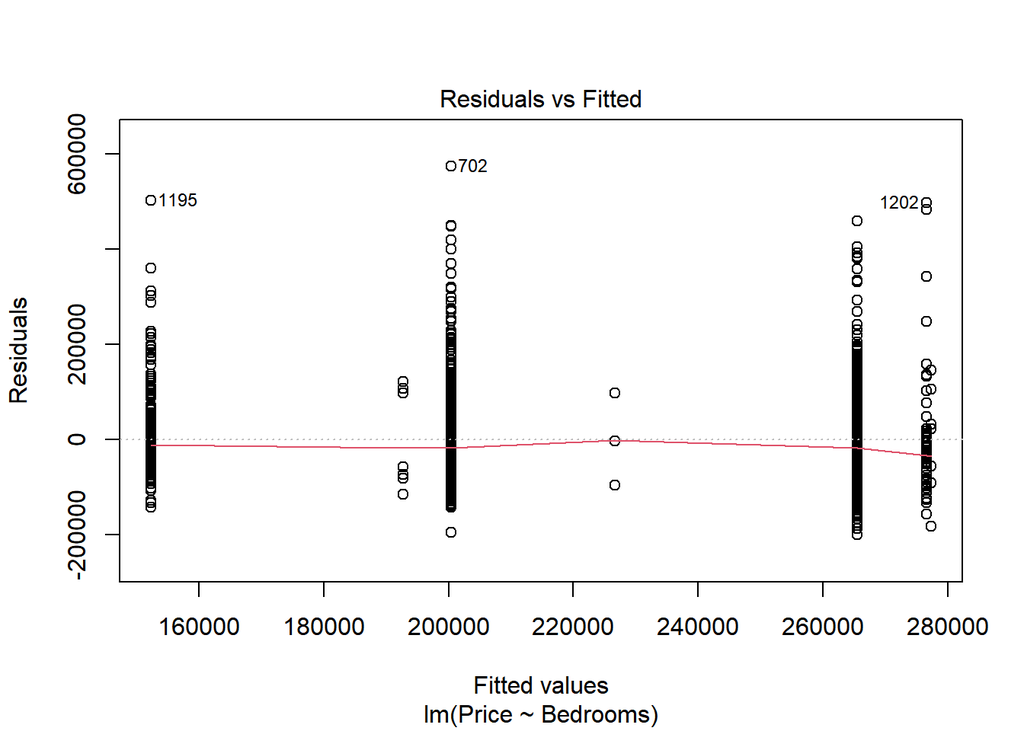

```r
plot(model6, which=1)
```

##Box plot of house price by Fireplaces & Analysis of Price ~ Fireplaces

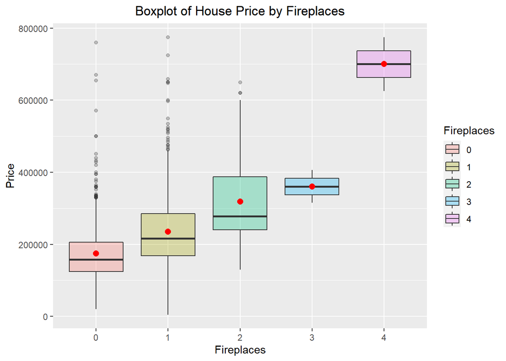

```r
ggplot(HP, aes(x=Fireplaces, y=Price, fill=Fireplaces)) +
  geom_boxplot(alpha=0.3) +
  stat_summary(fun.y=mean, geom="point", shape=20, size=4, color="red", fill="red")+
  ggtitle("Boxplot of House Price by Fireplaces")+
  theme(plot.title = element_text(hjust = 0.5))
```

```r
model7=lm(Price~Fireplaces,data=HP)
summary(model7)
```

```
##
## Call:
## lm(formula = Price ~ Fireplaces, data = HP)
##
## Residuals:
##     Min      1Q  Median      3Q     Max
## -230205  -57705  -18305   42753  585764
##
## Coefficients:
##             Estimate Std. Error t value             Pr(>|t|)
## (Intercept)   174236       3328  52.354 < 0.0000000000000002 ***
## Fireplaces1    60969       4453  13.690 < 0.0000000000000002 ***
## Fireplaces2   144586      14397  10.043 < 0.0000000000000002 ***
## Fireplaces3   186264      64275   2.898               0.0038 **
## Fireplaces4   525764      64275   8.180 0.000000000000000545 ***
## ---
## Signif. codes:  0 '***' 0.001 '**' 0.01 '*' 0.05 '.' 0.1 ' ' 1
##
## Residual standard error: 90780 on 1726 degrees of freedom
## Multiple R-squared:  0.1529, Adjusted R-squared:  0.1509
## F-statistic: 77.88 on 4 and 1726 DF,  p-value: < 0.00000000000000022
```